#### Dragos Ailoae

2021-10-25

# Multicollinearity

Sometimes explanatory variables are tightly connected and it is impossible to distinguish their individual influences on the dependent variable. Many economic variables may move together in some systematic way. Such variables are said to be collinear and cause the collinearity problem.

In the same way, multicollinearity refers to a situation in which **two or more** explanatory variables are highly linearly related. Consequently:

A set of variables is perfectly multicollinear if there exist one of more exact linear relationship among some of the variables. This means that if for a multiple regression model: $$ Y_{i}=\beta_{0}+\beta_{1} X_{1, i}+\ldots+\beta_{k} X_{k, i}+\epsilon_{i} $$ the following relationship holds true for $m$ explanatory variables: $$ \gamma_{0}+\gamma_{1} X_{1, i}+\ldots+\gamma_{k} X_{k, i}=0, \forall i=1, \ldots, N $$ for some $\gamma_{j} \neq 0, j=1, \ldots, k$. Then these $m$ variables exhibit multicollinearity and violate [assumption A2](https://ciresar.github.io/NYU/Lab_4/intro_univariate_regression.html) (See Greene Table 2.1 or Table 4.1).

## Perfect (or exact) collinearity

Perfect collinearity means that the $(X'X)$ matrix and singular and therefore cannot be inverted. As a consequence estimates for the OLS coefficients cannot be computed.

Let's first look at a simple, non-stochastic example:

```r
X <- matrix(c(2, 3,
             -2, 1,
              2, 2)
              ,byrow=T,nrow=3)
X
```

A matrix: 3 × 2 of type dbl

| 2 | 3 |
| --- | --- |
| -2 | 1 |
| 2 | 2 |

```r
X <- cbind(X, X[,1] + X[,2]*2)
X
```

A matrix: 3 × 3 of type dbl

| 2 | 3 | 8 |
| --- | --- | --- |
| -2 | 1 | 0 |
| 2 | 2 | 6 |

```r
XpX <- t(X)%*%X
XpX
paste('Matrix Dimension')
dim(XpX)
paste('Number of Rows: ',dim(XpX)[1])
paste('Number of Columns: ',dim(XpX)[2])
```

A matrix: 3 × 3 of type dbl

| 12 | 8 | 28 |
| --- | --- | --- |
| 8 | 14 | 36 |
| 28 | 36 | 100 |

'Matrix Dimension'

1. 3

2. 3

'Number of Rows: 3'

'Number of Columns: 3'

```r
qui <- suppressPackageStartupMessages # quiet! - suppress library load messages
qui(if(!require(Matrix)){install.packages('Matrix')}) # for 'rankMatrix' function

paste('Matrix Rank: ',rankMatrix(XpX))
```

'Matrix Rank: 2'

We can see that the $X'X$ matrix is not full rank. Consequently it cannot be inverted:

```r
solve(XpX)
```

```
Error in solve.default(XpX): Lapack routine dgesv: system is exactly singular: U[3,3] = 0
Traceback:

1. solve(XpX)
2. solve(XpX)
3. solve.default(XpX)
```

Always be mindful of the possible consequences of collinearity (which results in an non-invertible matrices in OLS calculation).

### Consequences of Multicollinearity

The situation of perfect collinearity virtually never arises in practice and can be disregarded. The relationship in real-world data is usually approximate.

In other words if the relationship is approximately linear: $$ X_{3, i} \approx \gamma_{0}+\gamma_{1} f\left(X_{1, i}\right)+\eta_{i}, \quad \eta_{i} \sim D\left(\mu_{\eta}, \sigma_{\eta}^{2}\right) $$ where $\eta$ is some kind of (not necessarily Gaussian) random variable. If $\eta$ is small, then $\operatorname{det}\left(\mathbf{X}^{\top} \mathbf{X}\right)$ is close to zero, then our data is close to multicollinear and $\left(\mathbf{X}^{\top} \mathbf{X}\right)^{-1}$ would be large, which would then result in imprecise estimators.

**Consequently multicollinearity results in multiple difficulties:**

- That the standard errors of the affected coefficients tend to be large. This results in failure to reject the null hypothesis on coefficient significance.
- Small changes to the input data can lead to large changes in the model, even resulting in changes of sign of parameter estimates. This is easier to verify if we estimate the same model on different subsets of the data and examine its coefficients.
- $R^{2}$ may be strangely large, which should be concerning when the model contains insignificant variables and variables with (economically) incorrect signs.
- The usual interpretation of a unit increase in $X_{j, i}$ effect on $Y$, holding all else constant (ceteris paribus) does not hold if the explanatory variables are correlated.
- In some sense, the collinear variables contain, at least partially, the same information about the dependent variable. A consequence of such data redundancy is overfitting.
- Depending on the software used, an approximate inverse of $\mathbf{X}^{\top} \mathbf{X}$ may be computed, although the resulting approximated inverse may be highly sensitive to slight variations in the data and so may be very inaccurate or very sample-dependent.

### Example

We will generate a simple example of two models of the following form: $$ \begin{aligned} &Y_{1, i}=\beta_{0}+\beta_{1} X_{1, i}+\beta_{2} X_{2, i}+\epsilon_{i} \\ &Y_{2, i}=\beta_{0}+\beta_{1} X_{1, i}+\beta_{2} X_{3, i}+\epsilon_{i} \end{aligned} $$ where $X_{1, i}$ and $X_{2, i}$ are independent, but but $X_{3, i}=\gamma_{0}+\gamma_{1} X_{1, i}$.

We'll then look at the case where $X_{3, i}$ is not perfectly collinear i.e. $X_{3, i}=2 - 2 X_{1, i}$ but approximately linear $$X_{3, i}=2-2 \cdot\left(X_{1, i}\right)^{0.9}+\eta_{i}, \quad \eta_{i} \sim \mathcal{N}(-2,1)$$

Let's set up the simulation and compare the first model with the perfectly collinear case:

```r
set.seed(123)

N = 200
beta_vec <- c(2, 4, -2)
x1 = rnorm(mean = 8, sd = 2, n = N)
x2 = rnorm(mean = 2, sd = 1, n = N)
x3 = 2 - 2 * x1
e  = rnorm(mean = 0, sd = 1, n = N)

y1 = cbind(1, x1, x2) %*% beta_vec + e
y2 = cbind(1, x1, x3) %*% beta_vec + e

dt1 <- data.frame(y1, x1, x2)
dt2 <- data.frame(y2, x1, x3)

mdl_1 <- lm(y1 ~ x1 + x2, data = dt1)
summary(mdl_1)
```

```
Call:
lm(formula = y1 ~ x1 + x2, data = dt1)

Residuals:
     Min       1Q   Median       3Q      Max
-2.86923 -0.57711  0.04882  0.66331  2.41531

Coefficients:
            Estimate Std. Error t value Pr(>|t|)
(Intercept)  2.26458    0.33338   6.793 1.27e-10 ***
x1           3.98380    0.03639 109.479  < 2e-16 ***
x2          -2.05066    0.06892 -29.754  < 2e-16 ***
---
Signif. codes:  0 '***' 0.001 '**' 0.01 '*' 0.05 '.' 0.1 ' ' 1

Residual standard error: 0.9679 on 197 degrees of freedom
Multiple R-squared:  0.9851,	Adjusted R-squared:  0.985
F-statistic:  6531 on 2 and 197 DF,  p-value: < 2.2e-16
```

```r
mdl_2 <- lm(y2 ~ x1 + x3, data = dt2)
summary(mdl_2)
```

```
Call:
lm(formula = y2 ~ x1 + x3, data = dt2)

Residuals:
     Min       1Q   Median       3Q      Max
-2.83465 -0.59224  0.06078  0.64298  2.46366

Coefficients: (1 not defined because of singularities)
            Estimate Std. Error t value Pr(>|t|)
(Intercept) -1.84478    0.29798  -6.191 3.38e-09 ***
x1           7.98454    0.03633 219.764  < 2e-16 ***
x3                NA         NA      NA       NA
---
Signif. codes:  0 '***' 0.001 '**' 0.01 '*' 0.05 '.' 0.1 ' ' 1

Residual standard error: 0.9668 on 198 degrees of freedom
Multiple R-squared:  0.9959,	Adjusted R-squared:  0.9959
F-statistic: 4.83e+04 on 1 and 198 DF,  p-value: < 2.2e-16
```

We see that the variable $X_{3}$ has NA values $-$ in other words, it is not included in our $\operatorname{lm}($ ) estimated regression which is why coef() does not return the row with $\mathrm{x} 3$ variable. Always be mindful of the possible consequences of collinearity (which results in an non-invertible matrices in OLS calculation). Econometric software is not always explicit in its methodology when some of these problems arise - it is usually assumed that the user if knowledgeable enough to identify these issues from the output, or by reading the software documentation.

Modifying our second model to be approximately linear: $$ X_{3, i}=2-2 \cdot\left(X_{1, i}\right)^{0.9}+\eta_{i}, \quad \eta_{i} \sim \mathcal{N}(-2,1) $$

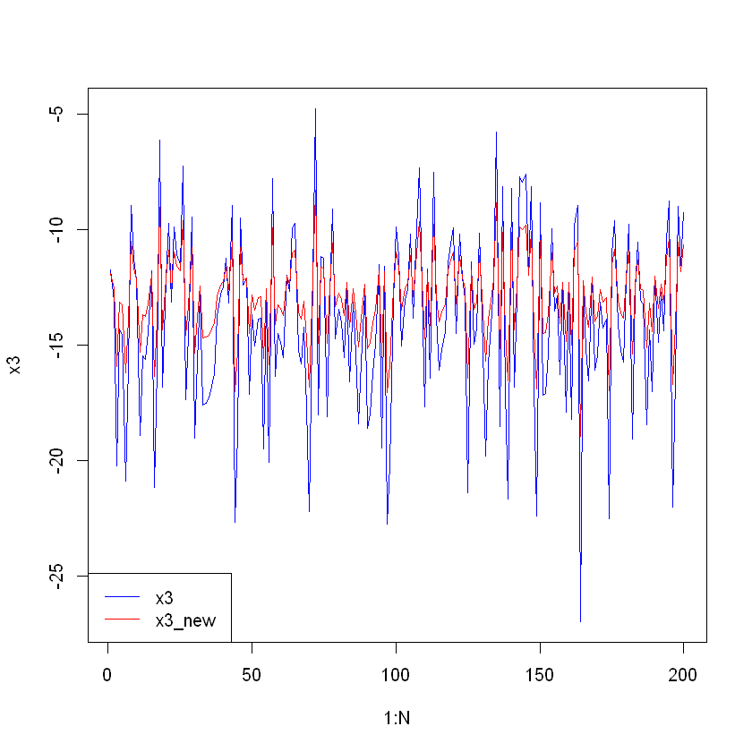

```r
set.seed(123)

x3_new = 2 - 2 * x1^(0.9) + rnorm(mean = -2, sd = 1, n = N)
y2_new = cbind(1, x1, x3_new) %*% beta_vec + e

plot(1:N, x3, type = "l", col = "blue")

lines(1:N, x3_new, col = "red")

legend("bottomleft", legend = c("x3", "x3_new"), col = c("blue", "red"), lty = 1)
```

```r
print(cor(cbind(x3, x3_new)))
```

```
              x3    x3_new
x3     1.0000000 0.9996801
x3_new 0.9996801 1.0000000
```

yields the following model coefficient estimates:

```r
dt3 <- data.frame(y2_new, x1, x3_new)
#
mdl_3 <- lm(y2_new ~ x1 + x3_new, data = dt3)
#
print(round(coef(summary(mdl_3)), 4))
```

```
            Estimate Std. Error t value Pr(>|t|)
(Intercept)   7.2029     7.9048  0.9112   0.3633
x1            4.9036     1.4387  3.4084   0.0008
x3_new       -1.0435     1.4969 -0.6971   0.4866
```

What makes matters worse is the $R^{2}$ and the $R_{a d j}^{2}$ of this model is very large:

```r
print(round(summary(mdl_3)$r.squared, 4))
```

```
[1] 0.9926
```

```r
print(round(summary(mdl_3)$adj.r.squared, 4))
```

```
[1] 0.9925
```

### Testing for Multicollinearity

A popular measure of multicollinearity is the variance inflation factor (VIF).

Consider the following multiple regression model:

$$ Y_{i}=\beta_{0}+\beta_{1} X_{1, i}+\ldots+\beta_{k} X_{k, i}+\epsilon_{k} $$

Then, the variance inflation factor of $\widehat{\beta}_{j}$ is evaluated in the following steps:

1. Run the OLS auxiliary regression (i.e. a regression, whose coefficients are not of direct interest) of $X_{j}$ as a function of all other explanatory variables: $$ X_{j, i}=\alpha_{0}+\alpha_{1} X_{1, i}+\ldots+\alpha_{j-1} X_{j-1, i}+\alpha_{j+1} X_{j+1, i}+\ldots+\alpha_{k} X_{k, i}+e_{i} $$
2. Then, the VIF of $\widehat{\beta}_{j}$ is: $$ \operatorname{VIF}\left(\widehat{\beta}_{j}\right)=\frac{1}{1-R_{j}^{2}} $$ where $R_{j}^{2}$ is the coefficient of determination of the regression in step (1).
3. Analyze the magnitude of multicollinearity from the size of $\operatorname{VIF}\left(\widehat{\beta}_{j}\right)$. as a rule of thumb:
- if $\operatorname{VIF}\left(\widehat{\beta}_{j}\right)>10$, then multicollinearity is high.
- if $\operatorname{VIF}\left(\widehat{\beta}_{j}\right)<5$, then the variable is not collinear with the remaining explanatory variables.

We can calculate the VIF manually:

```r
# VIF(x3_new)
1/(1 - summary(lm(x3_new ~ 1 + x1))$r.squared)
```

1563.27381161974

```r
# VIF(x1)
1/(1 - summary(lm(x1 ~ 1 + x3_new))$r.squared)
```

1563.27381161974

Or we can use the built-in functions to verify that the variables are clearly collinear:

```r
options(warn=-1) # Suppress warnings
qui <- suppressPackageStartupMessages # quiet! - suppress library load messages

# install (if not already installed) and load package
qui(if(!require(car)){install.packages('car')})  # for vif() function
print(vif(lm(y2_new ~ x1 + x3_new)))
```

```
      x1   x3_new
1563.274 1563.274
```

while for the model without collinearity the VIF is around 1 for each variable:

```r
print(vif(mdl_1))
```

```
      x1       x2
1.000768 1.000768
```